# Excellence in Agronomy (EiA) Initiative: LAC-Peru Use Case

A summary of progress

- **David A. Ramírez, Johan Ninanya, Javier Rinza, and Percy Briceño**
- **International Potato Center (CIP)**

# Background

This bookdown aims to summarize and document the analysis performed and findings obtained as part of the [**Excellence in Agronomy (EiA) Initiative**](https://www.cgiar.org/initiative/11-excellence-in-agronomy-eia-solutions-for-agricultural-transformation/) in **Latin America and the Caribbean (LAC)** region, specifically **Peru**. EiA is one of a series of [**CGIAR Initiatives**](https://www.cgiar.org/research/cgiar-portfolio/) that belongs to the **Environmental health & biodiversity** impact area and whose aim is *“to achieve sustainable intensification of smallholder farming systems, benefiting the agricultural resource base and its native organisms”*. Regarding the EiA LAC-Peru Use Case, the study area is located in the Chugay District, Sanchez Carrión Province, La Libertad region, and it is led by [**David A. Ramírez**](http://www.davidramirezc.com/) from [**CIP**](https://cipotato.org/) working hand in hand with local partners led by **Ronal Otiniano** from NGO [**Asociación Pataz**](https://www.asociacionpataz.org.pe/).

The main activities planned for the LAC-Peru Use Case were/are:

1. Agronomic data digitization using the e-Agrology platform (*in progress*).
2. Long-term demonstration trials of agronomic practices with potential for Climate Change mitigation (*in progress*).
3. Remote sensing techniques applied to the LAC-Peru Use Case (*in progress*).
4. Yield gap decomposition analysis (*in progress*).

For any request about the dataset or output/product generated and any comment about this bookdown, please contact DA Ramírez (**d.ramirez@cgiar.org**).

# 1 Agronomic data digitization

Agronomic data digitization involves the transformation of agricultural information—such as field observations, soil data, weather conditions, and crop health assessments—from analog or paper formats into digital ones. This process is pivotal for modernizing agricultural practices, enhancing efficiency, and making well-informed decisions through data analysis. Digitalization enables the efficient collection, storage, analysis, and visualization of agronomic data, facilitating precise decision-making and contributing to more sustainable farming practices.

## 1.1 e-Agrology platform

The e-Agrology platform (https://e-agrology.org/) is being used to collect general/relevant data about farmers, sowing events, used crops/varieties, technical visits to farmers’ plots, harvest events, and productivity (each of these is a log module of the e-Agrology). This platform has been developed by the CIMMYT team and it basically consists of well-thinking designed by experts surveys to obtain information directly from farmers.

[figure not shown]

Login window of the e-Agrology platform.

## 1.2 Data collection

Data collection was performed by surveying farmers mostly during April 2021 - June 2023 by using the ODK tool and then uploading the information to e-Agrology. Records for the six previously mentioned modules (farmer, sowing, crop, visit, harvest, and productivity) for about 600 farmers were planned to perform with support of CIP consultors and extensionist of AP. Till the middle of 2023, most modules are almost 100% done, with just the harvest and productivity modules being just at ~60% done. Since information related to inputs used by farmers (use of manure, fertilizers, etc.) is necessary for yield gap decomposition analysis, we plan to start recording data also for the “inputs” module of the e-Agrology in 2024. During 2023 an offline version of e-Agrology has been tested with encouraging results however some fixes are still needed.

## 1.3 Data cleaning up

```r
# clean R environment
# rm(list = ls())

# loading libraries
library(openxlsx)
library(dplyr)
library(stringr)
library(stringi)

# function to correct column names
correct_colnames <- function(x, omit.str, r.this = "[.]", w.this = "_"){
  x = tolower(x)
  x = stri_trans_general(x, id="Latin-ASCII")  # stringi package
  x = str_replace(x, omit.str, "")             # stringr package
  x = str_replace_all(x, r.this, w.this)       # stringr package
  return(x)
}

# function to check which data frame a variable belongs to
check_colnames_df <- function(df1, df2, both){
  cnames = unique(c(df1, df2))
  df = data.frame(cnames, in.df1 = FALSE, in.df2 = FALSE, in.both = FALSE)
  for(i in 1:nrow(df)){
    df$in.df1[i] = df$cnames[i] %in% df1
    df$in.df2[i] = df$cnames[i] %in% df2
    df$in.both[i] = ifelse(isTRUE(df$in.df1[i]) & isTRUE(df$in.df2[i]), TRUE, FALSE)
  }
  return(df)
}

# variable to save each agronomic log
LOG <- list()

################################################################################
# 1 - MERGING FARMERS LOGS
################################################################################
# read data
part1 <- "https://raw.githubusercontent.com/jninanya/eia-project-summary/main/CSVs/farmer-log-p1.csv"
part2 <- "https://raw.githubusercontent.com/jninanya/eia-project-summary/main/CSVs/farmer-log-p2.csv"

p1 <- read.csv(url(part1))
p2 <- read.csv(url(part2))

colnames(p1) <- correct_colnames(colnames(p1), omit.str = "data.")
colnames(p2) <- correct_colnames(colnames(p2), omit.str = "data.")

# This part is a bit manual
# Here we have to homogenize/rename different colnames of the same variable
# Lets run the next code line and see how its output change every running
check_colnames_df(colnames(p1), colnames(p2))

# after run 1: omit "agricultor_"
colnames(p1) <- correct_colnames(colnames(p1), omit.str = "agricultor_")

# after run 2: rename "name" (in p1) and "nombres" (in p2) to "farmer-name", and others
colnames(p1)[6] <- colnames(p2)[4] <- "farmer_name"
colnames(p1)[7] <- colnames(p2)[5] <- "father_last_name"
colnames(p1)[8] <- colnames(p2)[6] <- "mother_last_name"

# after run 3: rename "foto" (in p1) and "foto-productor" (in p2) to "photo"
colnames(p1)[10] <- colnames(p2)[8] <- "photo"

# after run 4: renaming some variable names
colnames(p1)[11] <- colnames(p2)[9] <- "birth_date"
colnames(p1)[12] <- colnames(p2)[10] <- "scolarship_level"
colnames(p1)[13] <- colnames(p2)[11] <- "phone_number"
colnames(p1)[14] <- colnames(p2)[12] <- "department"
colnames(p1)[15] <- colnames(p2)[13] <- "province"
colnames(p1)[16] <- colnames(p2)[14] <- "district"
colnames(p1)[17] <- colnames(p2)[15] <- "hamlet"
colnames(p1)[18] <- "other_hamlet"
colnames(p1)[19] <- colnames(p2)[16] <- "years_of_experience"
colnames(p1)[20] <- colnames(p2)[17] <- "organization_name"
colnames(p1)[21] <- "other_organization_name"
colnames(p1)[22] <- colnames(p2)[19] <- "coordinates"
colnames(p1)[23] <- colnames(p2)[20] <- "altitude"
colnames(p1)[24] <- colnames(p2)[21] <- "location_accuracy"
colnames(p1)[25] <- colnames(p2)[18] <- "plot_area"
colnames(p1)[26] <- colnames(p2)[22] <- "season"
colnames(p1)[27] <- colnames(p2)[23] <- "year"
colnames(p1)[28] <- colnames(p2)[24] <- "log_type"
colnames(p1)[29] <- colnames(p2)[25] <- "water_regime"
colnames(p1)[30] <- colnames(p2)[26] <- "project_name"
colnames(p1)[31] <- colnames(p2)[27] <- "project_type"
colnames(p1)[32] <- colnames(p2)[28] <- "production_type"
colnames(p1)[33] <- colnames(p2)[31] <- "crop"
colnames(p1)[34] <- colnames(p2)[32] <- "other_crop"
colnames(p1)[35] <- colnames(p2)[29] <- "crop2"
colnames(p1)[36] <- colnames(p2)[30] <- "other_crop2"
colnames(p1)[38] <- colnames(p2)[34] <- "variety_name"
colnames(p1)[39] <- colnames(p2)[35] <- "other_variety_name"
colnames(p1)[37] <- colnames(p2)[33] <- "seed_type"
colnames(p1)[40] <- colnames(p2)[36] <- "seed_cost"
colnames(p1)[41] <- colnames(p2)[37] <- "seed_amount"
colnames(p1)[42] <- colnames(p2)[38] <- "computation_method_of_seed_cost"
colnames(p1)[43] <- colnames(p2)[39] <- "main_product"
colnames(p1)[44] <- colnames(p2)[40] <- "seed_transportation_cost"
colnames(p1)[45] <- colnames(p2)[41] <- "seed_origin_point"
colnames(p1)[46] <- "other_seed_origin_point"
colnames(p1)[47] <- colnames(p2)[42] <- "seed_category"
colnames(p1)[48] <- colnames(p2)[43] <- "seed_time"
colnames(p1)[49] <- colnames(p2)[44] <- "place_of_purchased_seeds"
colnames(p1)[50] <- "other_place_of_purchased_seeds"
colnames(p1)[51] <- colnames(p2)[45] <- "reasons_to_use_seed_from_markets"
colnames(p1)[52] <- "other_reasons_to_use_seed_from_markets"
colnames(p1)[53] <- colnames(p2)[47] <- "land_possession"
colnames(p1)[54] <- colnames(p2)[48] <- "other_land_possession"
colnames(p1)[55] <- colnames(p2)[46] <- "property_type"

# after run 5: adding missing variables to p2
p2$other_hamlet <- NA
p2$other_organization_name <- NA
p2$other_seed_origin_point <- NA
p2$other_place_of_purchased_seeds <- NA
p2$other_reasons_to_use_seed_from_markets <- NA

# final colnames
check_colnames_df(colnames(p1), colnames(p2))
ccdf <- check_colnames_df(colnames(p1), colnames(p2))
cnames <- ccdf$cnames[ccdf$in.both]

# select final data frames
p1 <- p1[, cnames]
p2 <- p2[, cnames]
#full_join(p1, p2)

# changing type of variables
p1$dni <- as.numeric(p1$dni)
p2$dni <- as.numeric(p2$dni)
p1$birth_date <- convertToDate(p1$birth_date)
p2$birth_date <- convertToDate(p2$birth_date)
p1$phone_number <- as.numeric(p1$phone_number)
p2$phone_number <- as.numeric(p2$phone_number)
p1$years_of_experience <- as.numeric(p1$years_of_experience)
p2$years_of_experience <- as.numeric(p2$years_of_experience)
p1$altitude <- as.numeric(p1$altitude)
p2$altitude <- as.numeric(p2$altitude)
p1$location_accuracy <- as.numeric(p1$location_accuracy)
p2$location_accuracy <- as.numeric(p2$location_accuracy)
p1$plot_area <- as.numeric(p1$plot_area)
p2$plot_area <- as.numeric(p2$plot_area)
p1$year <- as.numeric(p1$year)
p2$year <- as.numeric(p2$year)
p1$seed_cost <- as.numeric(p1$seed_cost)
p2$seed_cost <- as.numeric(p2$seed_cost)
p1$seed_amount <- as.numeric(p1$seed_amount)
p2$seed_amount <- as.numeric(p2$seed_amount)
p1$seed_transportation_cost <- as.numeric(p1$seed_transportation_cost)
p2$seed_transportation_cost <- as.numeric(p2$seed_transportation_cost)
p1$seed_time <- as.numeric(p1$seed_time)
p2$seed_time <- as.numeric(p2$seed_time)

# final data frame for farmer log
L1 = full_join(p1, p2)
LOG[[1]] <- L1
names(LOG)[1] <- "farmer_log"
```

## 1.4 Data Analysis

### 1.4.1 General Overview of the study area

*under construction*

### 1.4.2 Preliminar typological analysis

Typological analysis in characterizing small-scale farmers proves invaluable for optimizing agricultural interventions and policies. By identifying distinct farmer profiles, tailored strategies can be developed to address specific challenges and opportunities within each group. This approach enhances resource allocation efficiency, improves intervention effectiveness, and provides a nuanced understanding of the diverse agricultural landscape. Ultimately, typological analysis serves as a crucial tool for informed decision-making, enabling policymakers to prioritize areas for intervention and monitor the impact of policies over time.

```r
library(missMDA)
library(FactoMineR)

data <- read.csv("csv/out_data_for_MCA.csv")
data <- as.data.frame(sapply(data, as.factor))

head(data)
```

```
##      X          cycle    gender experience s_plot_area      type_property
## 1 id_1  campana_chica masculino         50      medium comunal_asociacion
## 2 id_2  campana_chica masculino         50       small comunal_asociacion
## 3 id_3  campana_chica masculino         50       small comunal_asociacion
## 4 id_4  campana_chica masculino         20       small comunal_asociacion
## 5 id_5 campana_grande masculino         20       small comunal_asociacion
## 6 id_6 campana_grande masculino         50       small comunal_asociacion
##   possesion_land seed_type variety_name          seed_category
## 1         propia   criolla         high         semilla_propia
## 2         propia   criolla         high         semilla_propia
## 3         propia   criolla         high         semilla_propia
## 4      al partir   criolla       medium         semilla_propia
## 5         propia  mejorada          low semilla_no_certificada
## 6         propia   criolla       medium         semilla_propia
##   planting_time_factors     planting_type planting_method
## 1    demanda_de_mercado    ayuda_jornales            both
## 2            por_tiempo productor_familia            both
## 3            por_tiempo productor_familia            both
## 4            por_tiempo    ayuda_jornales            both
## 5            por_tiempo productor_familia            both
## 6            por_tiempo productor_familia            both
```

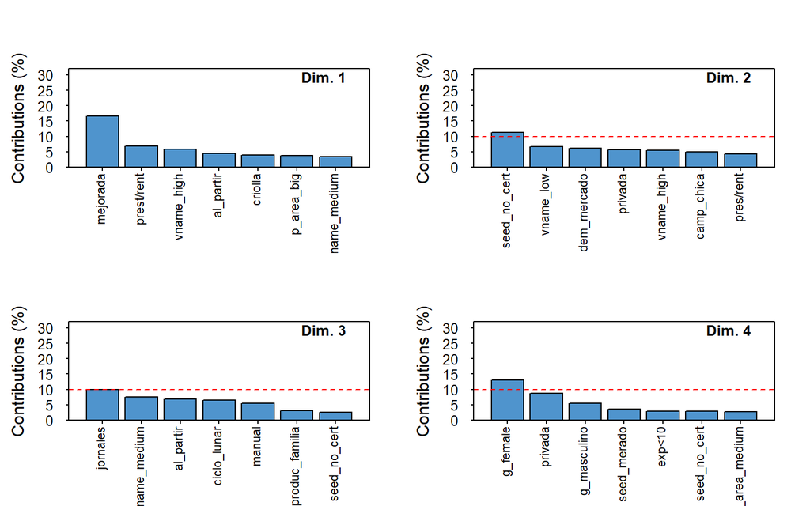

```r
#result<-estim_ncpMCA(data) #use to define how components must be selected
ncp = 5
res.mca <- MCA(data, graph = FALSE, ncp = 5)
#res.mca<-MCA(data, graph=FALSE, ncp=13)
#res.mca$eig

par(mfrow=c(2,2))


xdat<-sort(res.mca$var$contrib[,1],decreasing=TRUE)[1:7]
xnam=c("mejorada","prest/rent","vname_high","al_partir","criolla","p_area_big","vname_medium")
names(xdat)=NULL
h<-barplot(xdat, plot=FALSE)
barplot(xdat, xlim=c(0,h[length(xdat)]+h[1]), ylim=c(0,32),
        axes=FALSE, xlab="", ylab="", col="steelblue3", )
box()
abline(v=c(10), lty=2, col="red")
axis(side=1, xlim=c(0,h[length(xdat)]+h[1]), at=h, tck=-0.03,
     labels=NA, mgp = c(9,0.9,0), las=2)
axis(side=2, ylim=c(0,30), at=seq(0,30,by=5), tck=-0.03,
     labels=seq(0,30,by=5), mgp = c(9,0.9,0), las=1)
mtext(side=2, bquote("Contributions (%)"), line=2.5, cex=1)

text(h+0.2, -2, srt=90, adj=1.3, xpd=TRUE,
     labels=xnam, cex = 0.85, pos=2)
par(new=TRUE)
plot(x=NULL, y=NULL, axes=FALSE, xlim=c(-1,1), ylim=c(-1,1), xlab="", ylab="")
text(0.75, 0.9, expression(bold("Dim. 1")), cex=1.)


##################################################

xdat<-sort(res.mca$var$contrib[,2],decreasing=TRUE)[1:7]
xnam=c("seed_no_cert","vname_low","dem_mercado","privada","vname_high","camp_chica","pres/rent")
names(xdat)=NULL
h<-barplot(xdat, plot=FALSE)
barplot(xdat, xlim=c(0,h[length(xdat)]+h[1]), ylim=c(0,32),
        axes=FALSE, xlab="", ylab="", col="steelblue3", )
box()
abline(h=c(10), lty=2, col="red")
axis(side=1, xlim=c(0,h[length(xdat)]+h[1]), at=h, tck=-0.03,
     labels=NA, mgp = c(9,0.9,0), las=2)
axis(side=2, ylim=c(0,30), at=seq(0,30,by=5), tck=-0.03,
     labels=seq(0,30,by=5), mgp = c(9,0.9,0), las=1)
mtext(side=2, bquote("Contributions (%)"), line=2.5, cex=1.)

text(h+0.2, -2, srt=90, adj=1.3, xpd=TRUE,
     labels=xnam, cex = 0.85, pos=2)
par(new=TRUE)
plot(x=NULL, y=NULL, axes=FALSE, xlim=c(-1,1), ylim=c(-1,1), xlab="", ylab="")
text(0.75, 0.9, expression(bold("Dim. 2")), cex=1.)


##################################################

xdat<-sort(res.mca$var$contrib[,3],decreasing=TRUE)[1:7]
xnam=c("jornales","vname_medium","al_partir","ciclo_lunar","manual","produc_familia","seed_no_cert")
names(xdat)=NULL
h<-barplot(xdat, plot=FALSE)
barplot(xdat, xlim=c(0,h[length(xdat)]+h[1]), ylim=c(0,32),
        axes=FALSE, xlab="", ylab="", col="steelblue3", )
box()
abline(h=c(10), lty=2, col="red")
axis(side=1, xlim=c(0,h[length(xdat)]+h[1]), at=h, tck=-0.03,
     labels=NA, mgp = c(9,0.9,0), las=2)
axis(side=2, ylim=c(0,30), at=seq(0,30,by=5), tck=-0.03,
     labels=seq(0,30,by=5), mgp = c(9,0.9,0), las=1)
mtext(side=2, bquote("Contributions (%)"), line=2.5, cex=1.)

text(h+0.2, -2, srt=90, adj=1.3, xpd=TRUE,
     labels=xnam, cex = 0.85, pos=2)
par(new=TRUE)
plot(x=NULL, y=NULL, axes=FALSE, xlim=c(-1,1), ylim=c(-1,1), xlab="", ylab="")
text(0.75, 0.9, expression(bold("Dim. 3")), cex=1.)



##################################################

xdat<-sort(res.mca$var$contrib[,4],decreasing=TRUE)[1:7]
xnam=c("g_female","privada","g_masculino","seed_merado","exp<10","seed_no_cert","p_area_medium")
names(xdat)=NULL
h<-barplot(xdat, plot=FALSE)
barplot(xdat, xlim=c(0,h[length(xdat)]+h[1]), ylim=c(0,32),
        axes=FALSE, xlab="", ylab="", col="steelblue3", )
box()
abline(h=c(10), lty=2, col="red")
axis(side=1, xlim=c(0,h[length(xdat)]+h[1]), at=h, tck=-0.03,
     labels=NA, mgp = c(9,0.9,0), las=2)
axis(side=2, ylim=c(0,30), at=seq(0,30,by=5), tck=-0.03,
     labels=seq(0,30,by=5), mgp = c(9,0.9,0), las=1)
mtext(side=2, bquote("Contributions (%)"), line=2.5, cex=1.)

text(h+0.2, -2, srt=90, adj=1.3, xpd=TRUE,
     labels=xnam, cex = 0.85, pos=2)
par(new=TRUE)
plot(x=NULL, y=NULL, axes=FALSE, xlim=c(-1,1), ylim=c(-1,1), xlab="", ylab="")
text(0.75, 0.9, expression(bold("Dim. 4")), cex=1.)
```

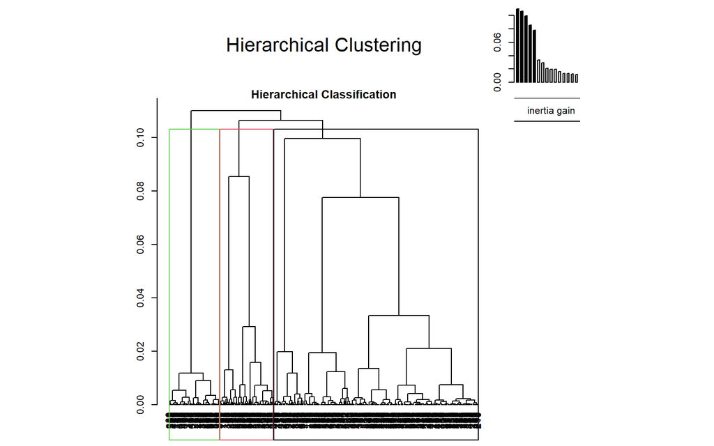

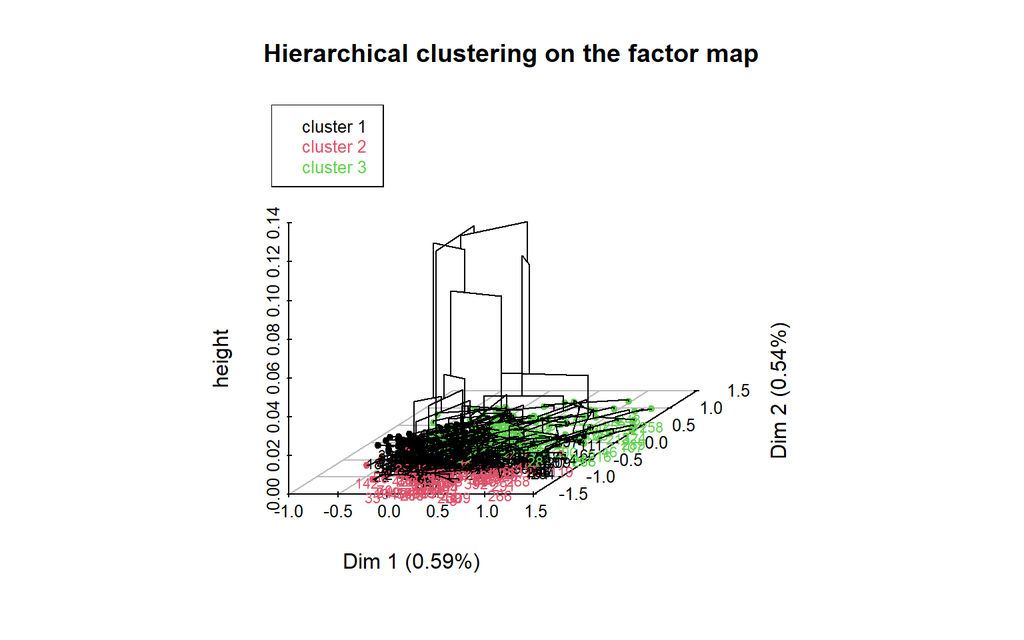

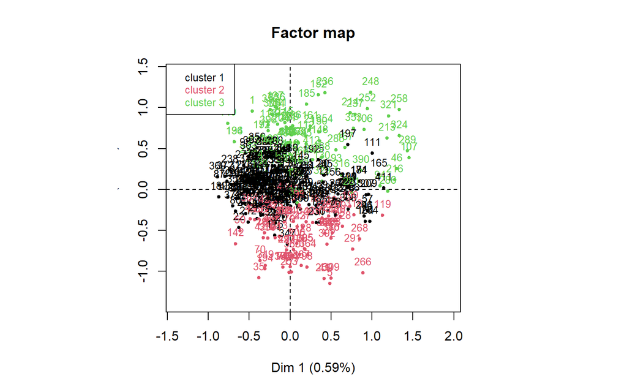

```r
#par(mfrow = c(1, 3))
res.hcpc<-HCPC(res.mca, nb.clust=3)
```

# 2 Long-term demonstration trials

*under construction*

# 3 Remote sensing tools

*under construction*

# 4 Yield Gap Decomposition

For this activity, We participated on a training in Ethiopia about yield gap decomposition analysis. Methods such as boundary line, stochastic frontier and machine learning were presented.

*more under construction*

## 4.1 Introduction

Purvey the future global food demand in a changing climate and rapidly increasing global population requires a sustainable intensification of food production. To this end, assessing the yield gap (Yg), i.e., the difference between the maximum or potential yield (Yp) and the farmer’s actual yield (Ya), in a cropping system is a critical activity.

## 4.2 Methodolgy

### 4.2.2 Stochastic frontiers analysis and yield gap decomposition

The stochastic frontier analysis will be used to estimate the technical efficient yield (YTEx), i. e., the maximum yield that can be achieved in farmers’ fields for a given level of inputs used. It is a parametric method that separates statistical noise and technical inefficiency in the production process. To perform this analysis, the R script implemented by Silva (2022) is being adapted/modified for our study case. Thus, data from e-Agrology will be cleaned and missing values for a particular variable will be imputed using the R package “missForest” if they are less than 20% of the total, otherwise that variable will be not considered for the analysis. Ya data will be obtained from the e-Agrology platform. Finally, yield gap will be decomposed as follows: i) Technology yield gap – Sum of sowing date yield gap (Ypa - Ypb) and genetic yield gap (Ypb - Ypc), ii) Resource yield gap – Difference between Ypc and YTEx, and iii) Efficiency yield gap – Difference between YTEx and Ya.

## 4.3 Data Analysis

*under construction*

## 4.4 Results

*under construction*

## 4.5 Apendix: Weather data retrieving from free publicly available sources

Weather data are important in agriculture and related sciences for activities planning, resources management, crop yield prediction, among others. However, sometimes there are no weather stations on site, so it is necessary to look for some alternatives to supply this need. This notebook aims to explain briefly how weather data can be retrieved from free publicly available sources using R.

**NOTE:** Do not forget that always the best data is the one measured on the site.

### 4.5.1 Library loading

For this, the following libraries will be used:

```r
library(nasapower)   # nasa database
library(rnoaa)       # noaa database
library(dplyr)       #
library(lubridate)   #
```

### 4.5.2 NASA POWER API Client

The NASA POWER API offers access to a wide range of global meteorological and solar energy data, supporting applications in climate research and renewable energy assessments. The rnasapower R package serves as a convenient client for interacting with this API within the R programming language. With capabilities for data retrieval, variable selection, geospatial analysis, and integration into R workflows, the package simplifies the process of accessing, processing, and utilizing NASA POWER data. Users can obtain historical or forecasted data for specific locations and time periods, making it a valuable tool for researchers and analysts in various fields. Access to the API requires an authentication key, and the package documentation provides guidance on installation and configuration for seamless integration into R-based data analysis pipelines. Lets see an example in the following R chunk code:

```r
# Specify the location and time period for the data
location <- c(40.7128, -74.0060)  # Latitude and longitude for New York City
start_date <- "2022-01-01"
end_date <- "2022-01-31"

# Specify the variables you want to retrieve (e.g., temperature and solar radiation)
variables <- c("T2M_MAX", "T2M_MIN", "ALLSKY_SFC_SW_DWN")

# Retrieve hourly data
ag_d <- get_power(
  community = "ag",
  lonlat = c(151.81, -27.48),
  pars = c("RH2M", "T2M", "PRECTOTCORR"),
  dates = c("2001-01-01", "2001-01-31"),
  temporal_api = "daily"
)
# View the first few rows of the data
head(ag_d)
```

```
## NASA/POWER CERES/MERRA2 Native Resolution Daily Data
##  Dates (month/day/year): 01/01/2001 through 01/31/2001
##  Location: Latitude  -27.48   Longitude 151.81
##  Elevation from MERRA-2: Average for 0.5 x 0.625 degree lat/lon region = 442.77 meters
##  The value for missing source data that cannot be computed or is outside of the sources availability range: NA
##  Parameter(s):
##
##  Parameters:
##  RH2M            MERRA-2 Relative Humidity at 2 Meters (%) ;
##  T2M             MERRA-2 Temperature at 2 Meters (C) ;
##  PRECTOTCORR     MERRA-2 Precipitation Corrected (mm/day)
##
## # A tibble: 6 × 10
##     LON   LAT  YEAR    MM    DD   DOY YYYYMMDD    RH2M   T2M PRECTOTCORR
##   <dbl> <dbl> <dbl> <int> <int> <int> <date>     <dbl> <dbl>       <dbl>
## 1  152. -27.5  2001     1     1     1 2001-01-01  64.5  19.9        0.2
## 2  152. -27.5  2001     1     2     2 2001-01-02  62.2  21.1        0.08
## 3  152. -27.5  2001     1     3     3 2001-01-03  60.8  21.5        0
## 4  152. -27.5  2001     1     4     4 2001-01-04  61.1  22.0        0
## 5  152. -27.5  2001     1     5     5 2001-01-05  60.8  22.2        0
## 6  152. -27.5  2001     1     6     6 2001-01-06  60.2  22.7        0
```

Wit this we can get a dataframe of weather data in a daily basis for a specific point (defined in the `lonlat` argument of **get_power()** function). Lets plot data for relative humidity (rhum), average temperature (temp), and precipitation (prec). Also we can get hourly data changig **daily** by **hourly** in the `temporal_api` argument.

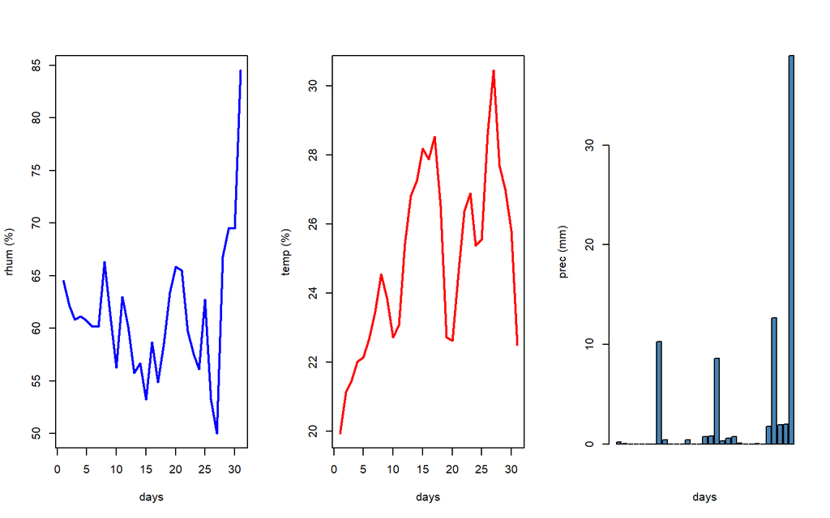

```r
par(mfrow = c(1, 3))
plot(ag_d$RH2M, type="l", xlab="days", ylab="rhum (%)", lwd=2, col="blue")
plot(ag_d$T2M, type="l", xlab="days", ylab="temp (%)", lwd=2, col="red")
barplot(ag_d$PRECTOTCORR, xlab="days", ylab="prec (mm)", col="steelblue")
```